# BadLoanDecisions

## [6 points] Q10.

Now, call *rpart* again using *loanTrain_balanced* and also add this parameter setting to rpart *control = rpart.control(cp = 0.001)*. Then, plot the tree again using *plot* command. *Tip:* The parameter *cp* is the complexity parameter that sets the threshold value for a decrease in overall lack of fit for any split. If *cp* is not met, further splits will no longer be pursued. *cp*’s default value is 0.01, but for complex problems, it is advised to relax *cp* (to a lower value). *Tip:* In your call to plot set *uniform = TRUE*. *Rubric:* 4 points for rpart, 2 points for plot.

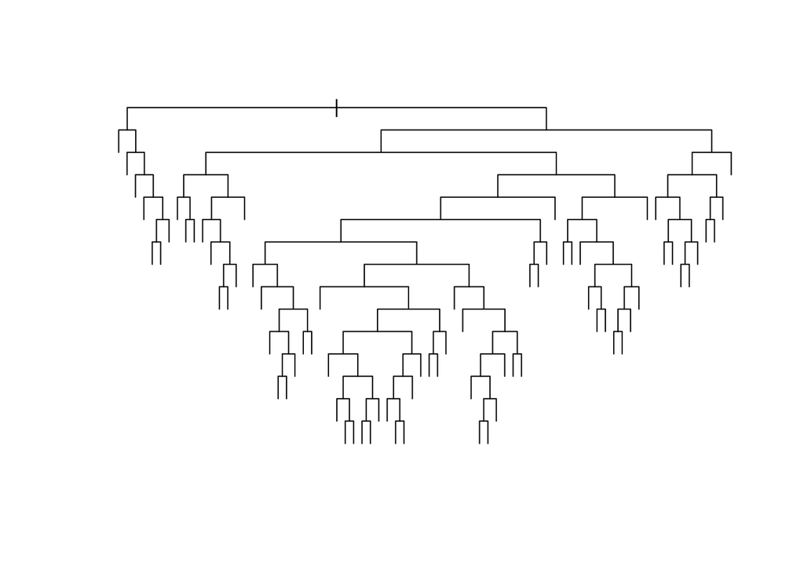

```r
tree_defaults_balanced = rpart(isLoanDefault ~ ., method="class", data = loanTrain_balanced,control = rpart.control(cp = 0.001)) #Add your "control" parameter code here#
plot(tree_defaults_balanced,uniform = TRUE)
```

## [1 point] Q11.

Now, stop and admire the beauty of what you just did for as long as you want! This is our tree and we will help it grow. Then, explain what was the effect of *uniform = TRUE*.

```r
### This section doesn't require code but feel free to reprint any critical values.
```

[figure not shown]

```r
tree_defaults_balanced_parms = rpart(isLoanDefault ~ ., method="class", data = loanTrain_balanced,control = rpart.control(cp = 0.001),parms = list(prior = c(0.67, 0.33)))
plot(tree_defaults_balanced_parms,uniform = TRUE)
text(tree_defaults_balanced_parms)
```

## [6 points] Q13.

Let’s continue to nurture our tree by including a loss matrix. You can do this by adding the following to the parms: *parms = list(loss = matrix(c(0, M, 1, 0), ncol = 2))*, where M is greater than 1. (This means an actual 1, predicted as 0 (i.e., a false negative) costs M times more that a false positive!) Choose an M that helps you improve the tree. Store the result in *tree_defaults_balanced_parms_lossmatrix*. *Tip:* Your parms parameter will now look like this: *parms = list(loss = matrix(c(0, M, 1, 0), ncol = 2), prior = c(0.67, 0.33))*. *Tip:* The loss matrix changes the relative importance of misclassification of a default as a non-default versus a non-default as a default. We are stressing that misclassifying a default as a non-default should be penalized more heavily. Including a loss matrix can again be done in the argument parms in the loss matrix: *parms = list(loss = matrix(c(0, cost_def_as_nondef, cost_nondef_as_def, 0), ncol=2))*. This constructs a 2x2-matrix with zeroes on the diagonal and changed loss penalties off-diagonal (by making the second parameter is higher). The default loss matrix is all ones off-diagonal, i.e, *c(0, 1, 1, 0))*. I suggest choosing something more than 5 for sure. Also, add *cex* parameter to the plot to scale the text size. text(tree_defaults_balanced_parms, cex = 0.25) *Rubric:* 4 points for rpart, 2 points for the plot.

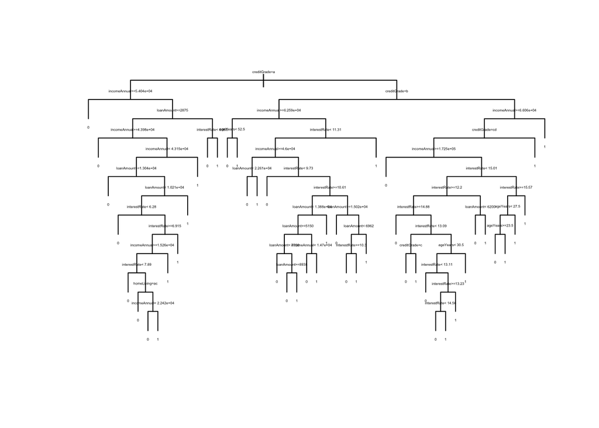

```r
tree_defaults_balanced_parms_lossmatrix = rpart(isLoanDefault ~ ., method="class", data = loanTrain_balanced,control = rpart.control(cp = 0.001),parms = list(loss = matrix(c(0, 2, 1, 0), ncol = 2)))
plot(tree_defaults_balanced_parms_lossmatrix,uniform = TRUE)
text(tree_defaults_balanced_parms_lossmatrix,cex = 0.25)
```

## [6 points] Q14.

Now, *prune* the *tree_defaults_balanced_parms_lossmatrix* tree using *prune* with a parameter between *0.001* and *0.004* and store the result in *tree_lovely*. Then, plot *tree_lovely* with text. *Tip:* Lots of work went into giving you that range. Don’t worry about that. Just choose a value that looks good to you. *Rubric:* 4 points for prune, 2 points for the plot.

[figure not shown]

```r
tree_lovely = prune(tree_defaults_balanced_parms_lossmatrix, cp = 0.003)
plot(tree_lovely)
text(tree_defaults_balanced_parms, cex = 0.5)
```

## [5 points] Q15.

Knit to html after eliminating all the errors. Submit both the Rmd and html files. Tip: Do not worry about minor formatting issues.* Tip: This will take some time as you are processing medium size data sets.

```r
### This section doesn't require code. Just knit and submit the Rmd and html files.###
```